# Midterm_retry_21600685

```r
library(dplyr)
library(tidyr)
library(stringr)
load("C:/Users/sec/Downloads/midterm2020 (1).RData")
```

# Data Exploration and Preparation

Q1.

```r
str(pums.sample)
```

```
## 'data.frame':    2672 obs. of  10 variables:
##  $ PINCP: num  22900 17800 56800 6100 12000 26300 7100 16200 31500 14000 ...
##  $ SEX  : num  1 2 1 2 2 2 2 2 1 1 ...
##  $ AGEP : num  43 51 55 23 23 73 49 42 56 42 ...
##  $ MAR  : num  1 1 1 5 5 2 2 5 1 1 ...
##  $ COW  : Factor w/ 7 levels "Employee of a private for-profit",..: 1 3 1 1 1 1 1 1 1 1 ...
##  $ SCHL : Factor w/ 9 levels "no high school diploma",..: 4 2 4 3 4 4 1 2 2 1 ...
##  $ WKHP : num  40 35 50 23 40 40 20 40 40 50 ...
##  $ FER  : Factor w/ 2 levels "no","yes": NA NA NA 2 1 NA 1 1 NA NA ...
##  $ JWMNP: num  5 40 15 28 10 30 50 10 10 60 ...
##  $ DIS  : Factor w/ 2 levels "w/disability",..: 2 2 1 2 2 1 1 2 2 2 ...
```

```r
head(pums.sample)
```

```
##   PINCP SEX AGEP MAR                              COW
## 1 22900   1   43   1 Employee of a private for-profit
## 2 17800   2   51   1        Local government employee
## 3 56800   1   55   1 Employee of a private for-profit
## 4  6100   2   23   5 Employee of a private for-profit
## 5 12000   2   23   5 Employee of a private for-profit
## 6 26300   2   73   2 Employee of a private for-profit
##                             SCHL WKHP  FER JWMNP           DIS
## 1 some college credit, no degree   40 <NA>     5 no disability
## 2    Regular high school diploma   35 <NA>    40 no disability
## 3 some college credit, no degree   50 <NA>    15  w/disability
## 4  GED or alternative credential   23  yes    28 no disability
## 5 some college credit, no degree   40   no    10 no disability
## 6 some college credit, no degree   40 <NA>    30  w/disability
```

observation의 수 : 2672 variable 의 수 : 10

sex, marital state의 경우 명목형 변수인데 수치 1, 2로 표현되어 적절히 설정되어 있지 않다. 이를 알맞은 factor형 변수로 바꾸어 주어야 한다.

Q2.

```r
pums.sample$SEX <- as.character(pums.sample$SEX)
pums.sample$SEX <- str_replace(pums.sample$SEX, "1", "Male")
pums.sample$SEX <- str_replace(pums.sample$SEX, "2", "Female")
pums.sample$SEX <- as.factor(pums.sample$SEX)
head(pums.sample$SEX)
```

```
## [1] Male   Female Male   Female Female Female
## Levels: Female Male
```

Q3.

```r
pums.sample$MAR <- as.character(pums.sample$MAR)
#pums.sample$MAR
named_vector <- c("1" = "Married", "2" = "Widowed", "3"= "Divorced", "4" = "Separated", "5" = "Never married or under 15 years old")

pums.sample$MAR <- sapply(pums.sample$MAR, function(x){named_vector[x]})

pums.sample$MAR <- as.factor(pums.sample$MAR)
head(pums.sample)
```

```
##   PINCP    SEX AGEP                                 MAR
## 1 22900   Male   43                             Married
## 2 17800 Female   51                             Married
## 3 56800   Male   55                             Married
## 4  6100 Female   23 Never married or under 15 years old
## 5 12000 Female   23 Never married or under 15 years old
## 6 26300 Female   73                             Widowed
##                                COW                           SCHL WKHP  FER
## 1 Employee of a private for-profit some college credit, no degree   40 <NA>
## 2        Local government employee    Regular high school diploma   35 <NA>
## 3 Employee of a private for-profit some college credit, no degree   50 <NA>
## 4 Employee of a private for-profit  GED or alternative credential   23  yes
## 5 Employee of a private for-profit some college credit, no degree   40   no
## 6 Employee of a private for-profit some college credit, no degree   40 <NA>
##   JWMNP           DIS
## 1     5 no disability
## 2    40 no disability
## 3    15  w/disability
## 4    28 no disability
## 5    10 no disability
## 6    30  w/disability
```

named_vector를 이용해 naming을 해준다. 우선 char형으로 MAR변수를 변환한 뒤에 naming을 sapply을 이용하여 적용해준다. 이후 명목형 변수이므로 factor로 치환해준다.

Q4.

```r
colSums(is.na(pums.sample))
```

```
## PINCP   SEX  AGEP   MAR   COW  SCHL  WKHP   FER JWMNP   DIS
##     0     0     0     0     6     0     0  1798   119     0
```

우선 FER, JWMNP, COW 변수의 경우 NA를 각각 1798개, 119개, 6개씩 포함하고 있고 나머지 변수들은 전부 NA값이 존재하지 않는다.

전체 관측치의 수는

```r
nrow(pums.sample)
```

```
## [1] 2672
```

2672이므로 이에 맞게 각각의 결과를 산출해줄 수 있다.

```r
1798*100/2672
```

```
## [1] 67.29042
```

FER변수의 경우 잔체의 67%가 NA이고

```r
119*100/2672
```

```
## [1] 4.453593
```

JWMNP변수의 경우 NA의 비중이 약 4%이고

```r
6*100/2672
```

```
## [1] 0.2245509
```

COW변수의 경우 약 0.22%가 NA비중임을 확인할 수 있다.

Q5.

```r
pums.sample.male <- pums.sample[which(pums.sample$SEX == "Male"), ]
nrow(pums.sample.male)
```

```
## [1] 1393
```

우선 남성의 전체 수는 1393명이다. 따로 남성들만 모아놓은 데이터 프레임에서 FER변수의 Missing value수를 구하기 위해 colsum을 사용하면

```r
colSums(is.na(pums.sample.male))
```

```
## PINCP   SEX  AGEP   MAR   COW  SCHL  WKHP   FER JWMNP   DIS
##     0     0     0     0     2     0     0  1393    64     0
```

1393으로 동일함을 확인할 수 있다. 즉 전체 남성이 전부 FER변수는 NA임을 확인할 수 있다.

반면 15세 미만의 여성의 경우

```r
pums.sample.female <- pums.sample[which(pums.sample$SEX == "Female"), ]
pums.sample.young_f <- filter(pums.sample.female, AGEP<15)
pums.sample.young_f
```

```
##  [1] PINCP SEX   AGEP  MAR   COW   SCHL  WKHP  FER   JWMNP DIS
## <0 rows> (or 0-length row.names)
```

데이터가 아예 존재하지 않음을 알 수 있다.

반면 50세 초과 여성의 경우

```r
pums.sample.old_f <- filter(pums.sample.female, AGEP>50)
nrow(pums.sample.old_f)
```

```
## [1] 405
```

```r
colSums(is.na(pums.sample.old_f))
```

```
## PINCP   SEX  AGEP   MAR   COW  SCHL  WKHP   FER JWMNP   DIS
##     0     0     0     0     2     0     0   405    18     0
```

405명의 모든 50세 초과 여성의 FER가 NA임을 확인할 수 있다.

Q6.

```r
summary(pums.sample)
```

```
##      PINCP            SEX            AGEP
##  Min.   : -8700   Female:1279   Min.   :16.00
##  1st Qu.: 16000   Male  :1393   1st Qu.:31.00
##  Median : 32000                 Median :43.00
##  Mean   : 45651                 Mean   :42.65
##  3rd Qu.: 56130                 3rd Qu.:53.00
##  Max.   :570000                 Max.   :84.00
##
##                                   MAR
##  Divorced                           : 316
##  Married                            :1492
##  Never married or under 15 years old: 747
##  Separated                          :  53
##  Widowed                            :  64
##
##
##                                COW                                   SCHL
##  Employee of a private for-profit:1716   some college credit, no degree:662
##  Private not-for-profit employee : 267   Regular high school diploma   :645
##  Local government employee       : 195   Bachelor's degree             :486
##  Self-employed not incorporated  : 187   no high school diploma        :272
##  State government employee       : 126   Associate's degree            :216
##  (Other)                         : 175   Master's degree               :209
##  NA's                            :   6   (Other)                       :182
##       WKHP         FER           JWMNP                  DIS
##  Min.   : 1.00   no  : 836   Min.   :  1.0   w/disability : 178
##  1st Qu.:35.00   yes :  38   1st Qu.: 10.0   no disability:2494
##  Median :40.00   NA's:1798   Median : 20.0
##  Mean   :38.21               Mean   : 25.6
##  3rd Qu.:40.00               3rd Qu.: 30.0
##  Max.   :99.00               Max.   :162.0
##                              NA's   :119
```

이중 주목하고 싶은 부분은 PINCP변수이다.

PINCP변수의 경우 연봉을 의미하는데 연봉이 -8700이라는 수치는 직관적으로 받아들여지지 않는 수치이다. 빚을 져서 그렇다고 한들, 실제로 그러한 수치는 소득을 산정하는데 반영이 안되기에 이는 이상치라고 간주할 수 있다.

```r
pums.sample[which.min(pums.sample$PINCP), ]
```

```
##     PINCP  SEX AGEP     MAR                            COW              SCHL
## 431 -8700 Male   40 Married Self-employed not incorporated Bachelor's degree
##     WKHP  FER JWMNP           DIS
## 431   40 <NA>    20 no disability
```

해당 사람에 대해 세부적인 내용을 살펴보면, 자영업을 하는 사람이고 학사 학위이며 주당 40시간 정도의 일을 하는 사람임을 알 수 있다. 적자의 상황을 반영했다하면 이상치가 아닐 수 있지만, 통상적으로 소득 수준을 판단할 때 -소득을 반영했는 지의 여부를 검토해볼 필요가 있다.

Q7. 학위에 따른 직업군의 분포 양상을 대강 확인하면

```r
table(pums.sample$COW, pums.sample$SCHL)
```

```
##
##                                    no high school diploma
##   Employee of a private for-profit                    210
##   Private not-for-profit employee                      15
##   Local government employee                            15
##   State government employee                             3
##   Federal government employee                           2
##   Self-employed not incorporated                       24
##   Self-employed incorporated                            3
##
##                                    Regular high school diploma
##   Employee of a private for-profit                         459
##   Private not-for-profit employee                           49
##   Local government employee                                 39
##   State government employee                                 15
##   Federal government employee                               11
##   Self-employed not incorporated                            43
##   Self-employed incorporated                                28
##
##                                    GED or alternative credential
##   Employee of a private for-profit                            55
##   Private not-for-profit employee                              8
##   Local government employee                                    6
##   State government employee                                    8
##   Federal government employee                                  3
##   Self-employed not incorporated                              10
##   Self-employed incorporated                                   3
##
##                                    some college credit, no degree
##   Employee of a private for-profit                            451
##   Private not-for-profit employee                              62
##   Local government employee                                    38
##   State government employee                                    28
##   Federal government employee                                  14
##   Self-employed not incorporated                               48
##   Self-employed incorporated                                   18
##
##                                    Associate's degree Bachelor's degree
##   Employee of a private for-profit                134               283
##   Private not-for-profit employee                  26                56
```

[output cut: 8 more lines]

```
##   Private not-for-profit employee               34                  10
##   Local government employee                     32                   7
##   State government employee                     21                   0
##   Federal government employee                   11                   4
##   Self-employed not incorporated                13                   6
##   Self-employed incorporated                    10                   7
##
##                                    Doctorate degree
##   Employee of a private for-profit               12
##   Private not-for-profit employee                 7
##   Local government employee                       2
##   State government employee                       7
##   Federal government employee                     0
##   Self-employed not incorporated                  3
##   Self-employed incorporated                      0
```

다음과 같다. 이를 조금 더 확률적으로 보기 위해 prop.table()을 활용하면

```r
tble <- prop.table(table(pums.sample$COW, pums.sample$SCHL))
tble
```

```
##
##                                    no high school diploma
##   Employee of a private for-profit           0.0787696924
##   Private not-for-profit employee            0.0056264066
##   Local government employee                  0.0056264066
##   State government employee                  0.0011252813
##   Federal government employee                0.0007501875
##   Self-employed not incorporated             0.0090022506
##   Self-employed incorporated                 0.0011252813
##
##                                    Regular high school diploma
##   Employee of a private for-profit                0.1721680420
##   Private not-for-profit employee                 0.0183795949
##   Local government employee                       0.0146286572
##   State government employee                       0.0056264066
##   Federal government employee                     0.0041260315
##   Self-employed not incorporated                  0.0161290323
##   Self-employed incorporated                      0.0105026257
##
##                                    GED or alternative credential
##   Employee of a private for-profit                  0.0206301575
##   Private not-for-profit employee                   0.0030007502
##   Local government employee                         0.0022505626
##   State government employee                         0.0030007502
##   Federal government employee                       0.0011252813
##   Self-employed not incorporated                    0.0037509377
##   Self-employed incorporated                        0.0011252813
##
##                                    some college credit, no degree
##   Employee of a private for-profit                   0.1691672918
##   Private not-for-profit employee                    0.0232558140
##   Local government employee                          0.0142535634
##   State government employee                          0.0105026257
##   Federal government employee                        0.0052513128
##   Self-employed not incorporated                     0.0180045011
##   Self-employed incorporated                         0.0067516879
##
##                                    Associate's degree Bachelor's degree
##   Employee of a private for-profit       0.0502625656      0.1061515379
##   Private not-for-profit employee        0.0097524381      0.0210052513
```

[output cut: 8 more lines]

```
##   Private not-for-profit employee     0.0127531883        0.0037509377
##   Local government employee           0.0120030008        0.0026256564
##   State government employee           0.0078769692        0.0000000000
##   Federal government employee         0.0041260315        0.0015003751
##   Self-employed not incorporated      0.0048762191        0.0022505626
##   Self-employed incorporated          0.0037509377        0.0026256564
##
##                                    Doctorate degree
##   Employee of a private for-profit     0.0045011253
##   Private not-for-profit employee      0.0026256564
##   Local government employee            0.0007501875
##   State government employee            0.0026256564
##   Federal government employee          0.0000000000
##   Self-employed not incorporated       0.0011252813
##   Self-employed incorporated           0.0000000000
```

각 직업별로 확인을 할 수 있는데 우선 순차적으로 no high school diploma부터 확인해보면

```r
tble[, 1]
```

```
## Employee of a private for-profit  Private not-for-profit employee
##                     0.0787696924                     0.0056264066
##        Local government employee        State government employee
##                     0.0056264066                     0.0011252813
##      Federal government employee   Self-employed not incorporated
##                     0.0007501875                     0.0090022506
##       Self-employed incorporated
##                     0.0011252813
```

이를 하나하나 시각화해서 보다 쉽게 표현을 하면

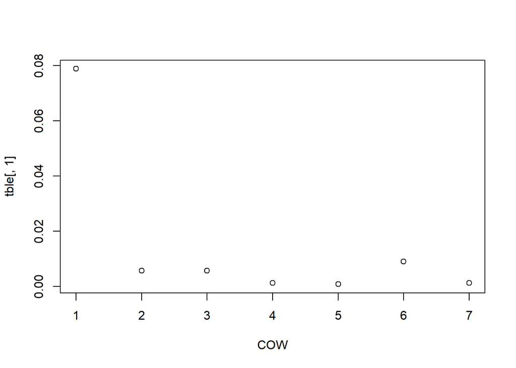

```r
plot(tble[, 1], xlab = 'COW')
```

no high school diploma의 경우 Employee of a private for-profit(1번)의 확률이 0.08정도로 다른 직업군에 비해서 상대적인 비율이 매우 높음을 확인할 수 있다.

다른 직업군들도 대체적으로 Employee of a private for-profit의 비율이 높음을 확인할 수 있다.

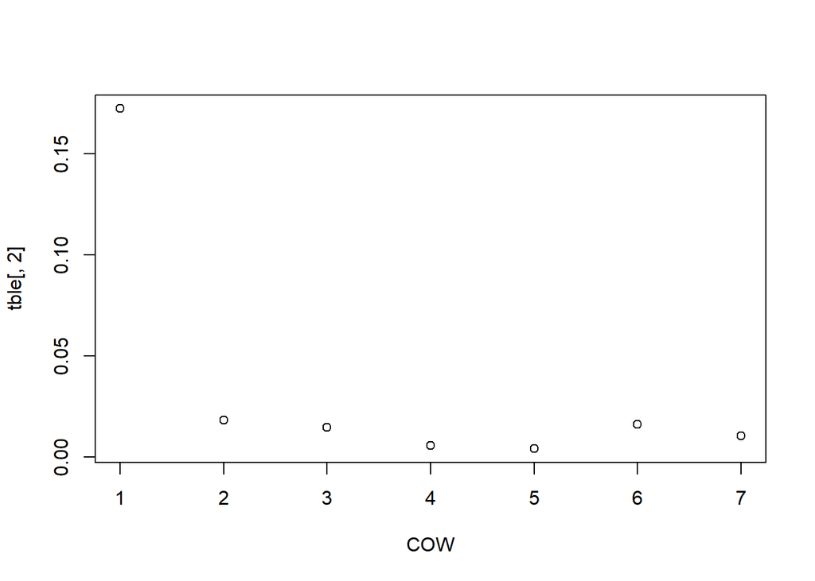

```r
plot(tble[,2], xlab = 'COW')
```

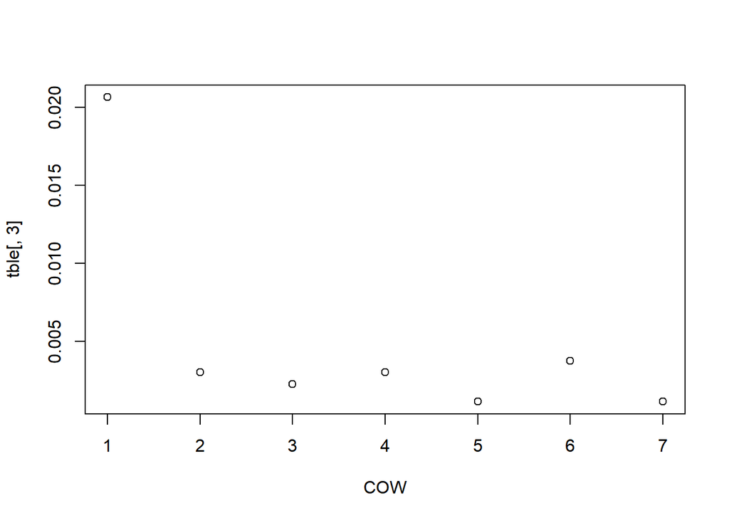

```r
plot(tble[,3], xlab = 'COW')
```

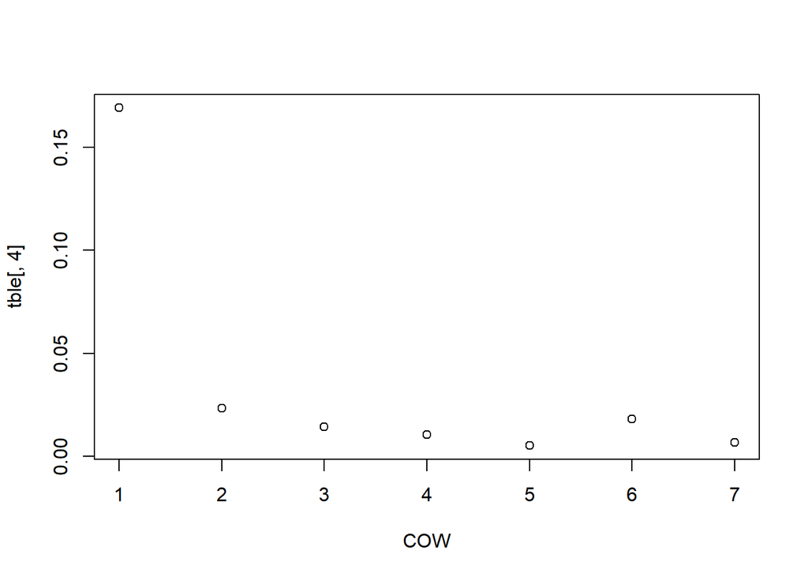

```r
plot(tble[,4], xlab = 'COW')
```

학사

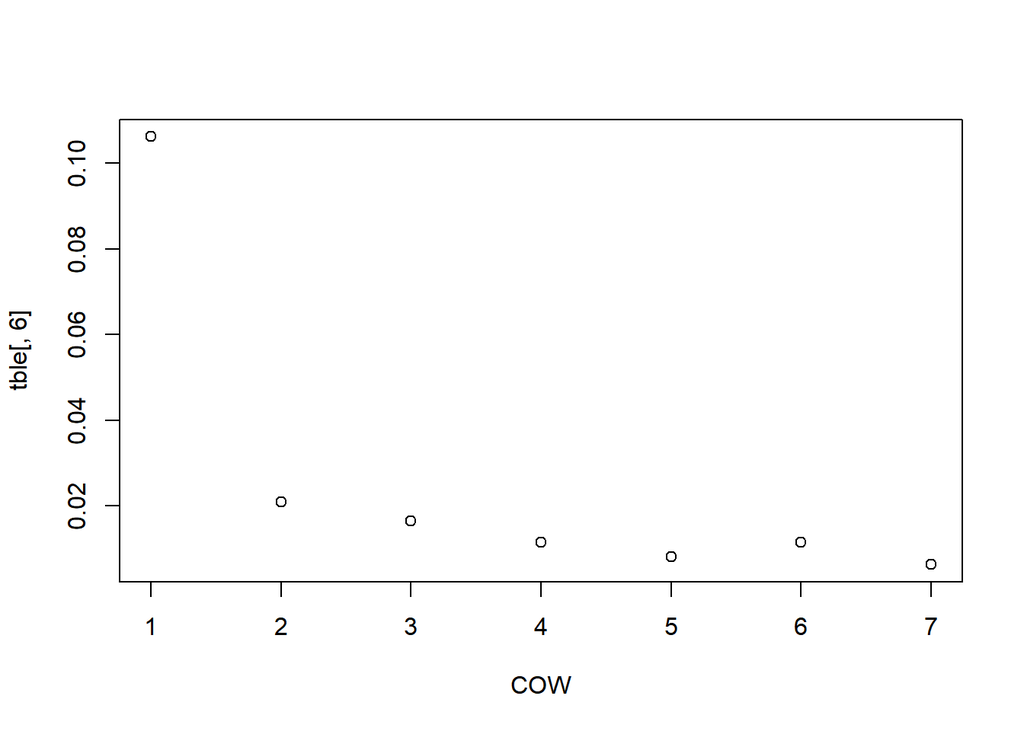

```r
plot(tble[,6], xlab = 'COW')
```

석사

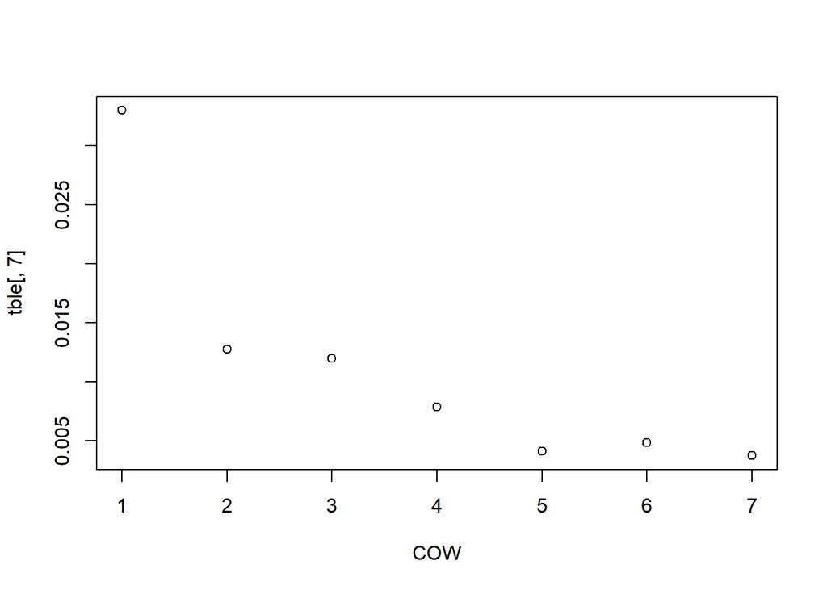

```r
plot(tble[,7], xlab = 'COW')
```

전문 학위(Professional Degree)

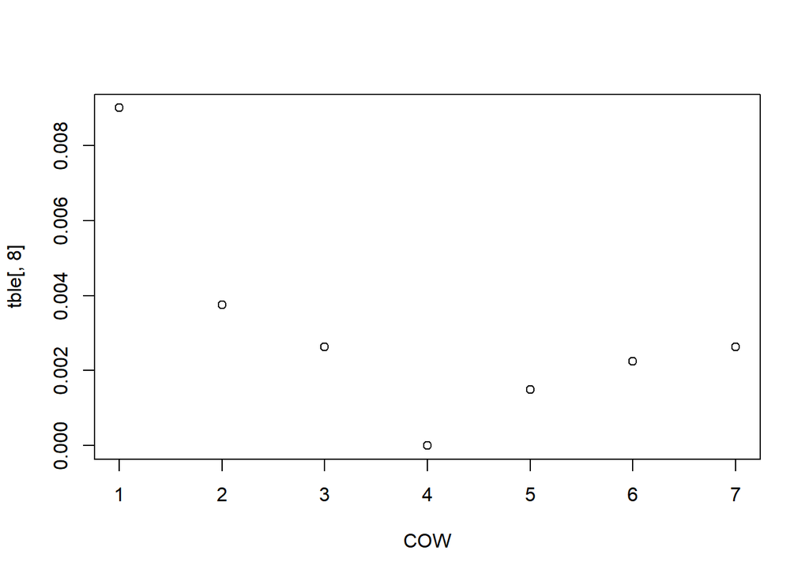

```r
plot(tble[,8], xlab = 'COW')
```

Q8.

```r
cut_point <- cut(pums.sample$AGEP, breaks = c(20,30,40,50,60,84), right = F, labels = c("20s", "30s", "40s", "50s", "over 60s"))
#cut_point
cut_point[is.na(cut_point)] <- "20s"

pums.sample$age_group <- cut_point
tapply(pums.sample$PINCP, pums.sample$age_group, mean)
```

```
##      20s      30s      40s      50s over 60s
## 21330.84 48491.21 51634.66 55747.96 55987.23
```

60대가 가장 소득이 높고 20대가 소득이 가장 낮음을 확인할 수 있다.

Q9. 주간 근무 시간과 연 소득을 비교하는 plot그래프를 그려보면

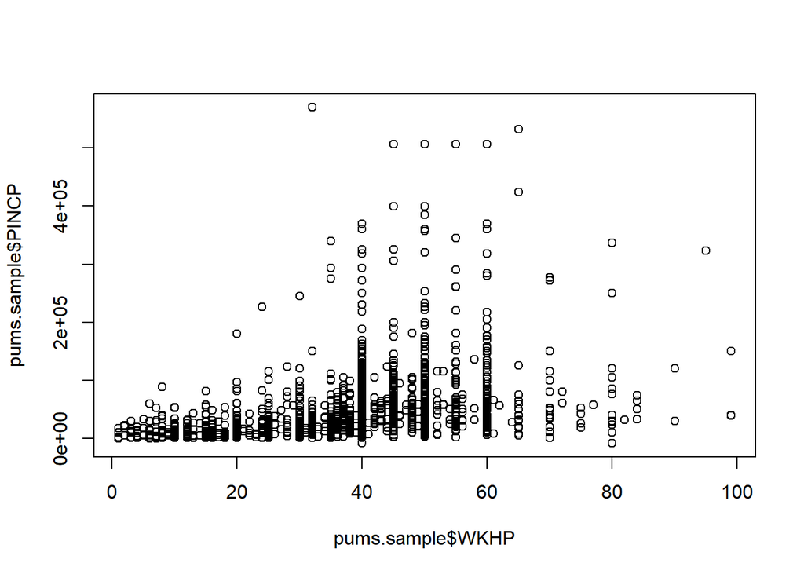

```r
plot(pums.sample$WKHP, pums.sample$PINCP)
```

명확한 상관관계가 있는 지의 여부를 확인하기 어렵다.

표본 상관계수르 구해보면

```r
cor(pums.sample$WKHP, pums.sample$PINCP)
```

```
## [1] 0.3670258
```

그다지 큰 연관성이 있어보이지는 않았다.

WKHP변수를 보다 명확히 group화 해서 비교를 하기 위해 WKHP변수의 대강의 histogram을 살펴보면

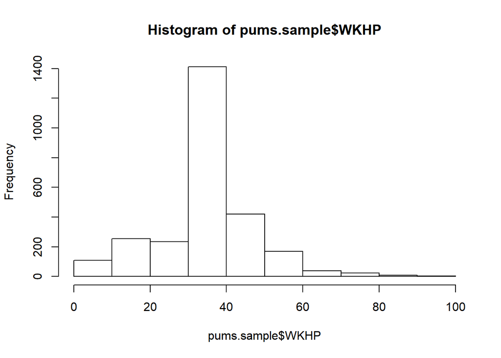

```r
hist(pums.sample$WKHP)
```

group화를 해준다, 총 5개의 level을 갖는 factor형으로 변환해준다.

```r
pums.sample$W_group <- cut(pums.sample$WKHP, breaks = c(0, 20, 40, 60, 80, 100), right = F, labels = c('low', 'semi low', 'middle', 'semi high', 'high'))
```

그룹화해준 변수를 회귀식을 돌려보면

```r
summary(lm(pums.sample$PINCP~pums.sample$W_group))
```

```
##
## Call:
## lm(formula = pums.sample$PINCP ~ pums.sample$W_group)
##
## Residuals:
##    Min     1Q Median     3Q    Max
## -90726 -23040 -10345   6982 543255
##
## Coefficients:
##                              Estimate Std. Error t value Pr(>|t|)
## (Intercept)                     12181       3203   3.803 0.000146 ***
## pums.sample$W_groupsemi low     14565       3802   3.831 0.000131 ***
## pums.sample$W_groupmiddle       40860       3426  11.925  < 2e-16 ***
## pums.sample$W_groupsemi high    73440       5204  14.113  < 2e-16 ***
## pums.sample$W_grouphigh         70545      10091   6.991 3.44e-12 ***
## ---
## Signif. codes:  0 '***' 0.001 '**' 0.01 '*' 0.05 '.' 0.1 ' ' 1
##
## Residual standard error: 49720 on 2667 degrees of freedom
## Multiple R-squared:  0.1134, Adjusted R-squared:  0.1121
## F-statistic:  85.3 on 4 and 2667 DF,  p-value: < 2.2e-16
```

R2가 0.1 정도 나와 예측력이 높다고 할 수는 없지만 Estimate값을 살펴보면 대체적으로 일한 시간이 많을 수록 소득과 양의 상관관계가 강함을 확인할수 있고 p_value가 대체적으로 유의하게 나옴을 확인할 수 있다.

보다 정확한 분석을 위해 목표 변수에 log를 취해준 결과랑 비교를 해보면

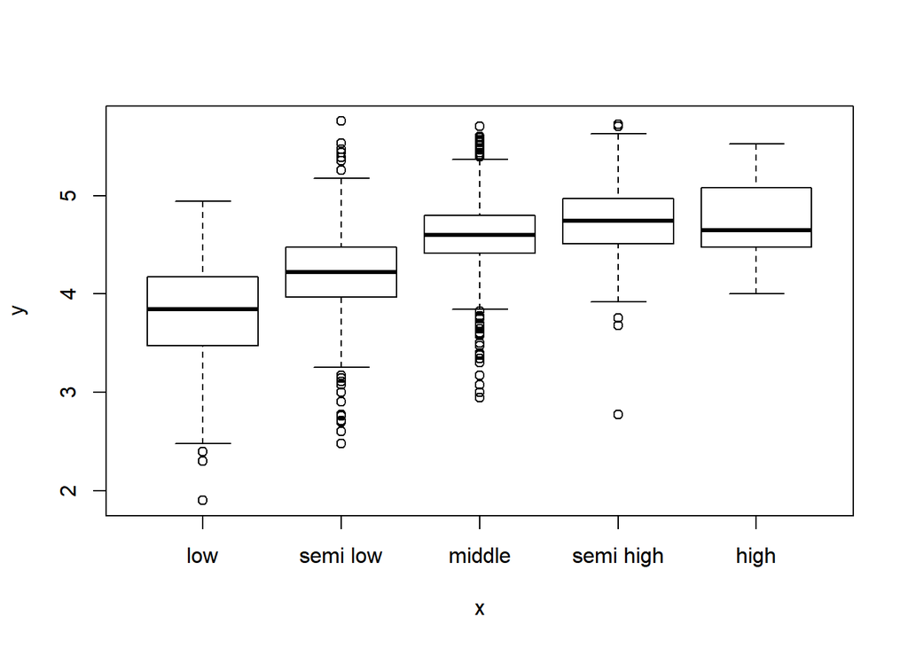

```r
plot(pums.sample$W_group, log10(pums.sample$PINCP))
```

전반적으로 양의 상관관계를 갖는 것처럼 보였다.

Q10. 구축한 데이터프레임을 저장해준다.

```r
save(pums.sample, file = "21600685.retry.RData")
```

# Data Transformation

Q1. iris 데이터를 문제 셋이 원하는 대로 변형을 시켜주기 위해서는 우선 첫번째로 고유의 id를 부여해준다.

```r
iriss <- iris
head(iriss)
```

```
##   Sepal.Length Sepal.Width Petal.Length Petal.Width Species
## 1          5.1         3.5          1.4         0.2  setosa
## 2          4.9         3.0          1.4         0.2  setosa
## 3          4.7         3.2          1.3         0.2  setosa
## 4          4.6         3.1          1.5         0.2  setosa
## 5          5.0         3.6          1.4         0.2  setosa
## 6          5.4         3.9          1.7         0.4  setosa
```

```r
iriss$id <- 1:150
head(iriss)
```

```
##   Sepal.Length Sepal.Width Petal.Length Petal.Width Species id
## 1          5.1         3.5          1.4         0.2  setosa  1
## 2          4.9         3.0          1.4         0.2  setosa  2
## 3          4.7         3.2          1.3         0.2  setosa  3
## 4          4.6         3.1          1.5         0.2  setosa  4
## 5          5.0         3.6          1.4         0.2  setosa  5
## 6          5.4         3.9          1.7         0.4  setosa  6
```

gather함수를 취해본다

```r
iriss <- gather(iriss, Part, value, 1:4)
head(iriss)
```

```
##   Species id         Part value
## 1  setosa  1 Sepal.Length   5.1
## 2  setosa  2 Sepal.Length   4.9
## 3  setosa  3 Sepal.Length   4.7
## 4  setosa  4 Sepal.Length   4.6
## 5  setosa  5 Sepal.Length   5.0
## 6  setosa  6 Sepal.Length   5.4
```

우선 Part 안에 있는 Sepal 부분과 Length부분을 나누워주기 위해 separate함수를 사용한다.

```r
iriss <- separate(iriss, Part, into = c('Part', 'Char'))
head(iriss)
```

```
##   Species id  Part   Char value
## 1  setosa  1 Sepal Length   5.1
## 2  setosa  2 Sepal Length   4.9
## 3  setosa  3 Sepal Length   4.7
## 4  setosa  4 Sepal Length   4.6
## 5  setosa  5 Sepal Length   5.0
## 6  setosa  6 Sepal Length   5.4
```

이를 다시 spread해준다. 기존에 id를 부여해서 spread가 가능하다

```r
iriss <- spread(iriss, Char, value)
head(iriss)
```

```
##   Species id  Part Length Width
## 1  setosa  1 Petal    1.4   0.2
## 2  setosa  1 Sepal    5.1   3.5
## 3  setosa  2 Petal    1.4   0.2
## 4  setosa  2 Sepal    4.9   3.0
## 5  setosa  3 Petal    1.3   0.2
## 6  setosa  3 Sepal    4.7   3.2
```

이를 원하는 데이터셋에 구축한다.

```r
iris.tidy <- iriss[, c('Species', 'Part', 'Length', 'Width')]
head(iris.tidy)
```

```
##   Species  Part Length Width
## 1  setosa Petal    1.4   0.2
## 2  setosa Sepal    5.1   3.5
## 3  setosa Petal    1.4   0.2
## 4  setosa Sepal    4.9   3.0
## 5  setosa Petal    1.3   0.2
## 6  setosa Sepal    4.7   3.2
```

Q2.

```r
iriss2 <- iris
iriss2$id <- 1:150
head(iriss2)
```

```
##   Sepal.Length Sepal.Width Petal.Length Petal.Width Species id
## 1          5.1         3.5          1.4         0.2  setosa  1
## 2          4.9         3.0          1.4         0.2  setosa  2
## 3          4.7         3.2          1.3         0.2  setosa  3
## 4          4.6         3.1          1.5         0.2  setosa  4
## 5          5.0         3.6          1.4         0.2  setosa  5
## 6          5.4         3.9          1.7         0.4  setosa  6
```

우선 마찬가지로 동일하게 id부여후 gather를 해준다.

```r
iriss2 <- gather(iriss2, Part, value, 1:4)
head(iriss2)
```

```
##   Species id         Part value
## 1  setosa  1 Sepal.Length   5.1
## 2  setosa  2 Sepal.Length   4.9
## 3  setosa  3 Sepal.Length   4.7
## 4  setosa  4 Sepal.Length   4.6
## 5  setosa  5 Sepal.Length   5.0
## 6  setosa  6 Sepal.Length   5.4
```

Part 부분을 쪼개주기 위해 separate함수 사용

```r
iriss2 <- separate(iriss2, Part, into = c('Part', 'Measure'))
head(iriss2)
```

```
##   Species id  Part Measure value
## 1  setosa  1 Sepal  Length   5.1
## 2  setosa  2 Sepal  Length   4.9
## 3  setosa  3 Sepal  Length   4.7
## 4  setosa  4 Sepal  Length   4.6
## 5  setosa  5 Sepal  Length   5.0
## 6  setosa  6 Sepal  Length   5.4
```

이를 원하는 데이터셋에 저장한다.

```r
iris.wide <- iriss2[, c('Species', 'Part', 'Measure', 'value')]
head(iris.wide)
```

```
##   Species  Part Measure value
## 1  setosa Sepal  Length   5.1
## 2  setosa Sepal  Length   4.9
## 3  setosa Sepal  Length   4.7
## 4  setosa Sepal  Length   4.6
## 5  setosa Sepal  Length   5.0
## 6  setosa Sepal  Length   5.4
```

```r
save(pums.sample, iris.tidy, iris.wide, file = "21600685.retry.RData")
```